# slimy: (Monte Carlo) SampLIng-based Method for causalitY

2018-08-27

The R package `slimy` implements Markov chain Monte Carlo sampling-based inference of causal graphs from empirical discrete or continuous data. The default algorithm is Gibbs sampling with blocking schemes proposed by Goudie and Mukherjee (GM)<sup>1</sup> using partitioning of parent sets for randomly selected nodes. We illustrate the basic usage below using random graphs and simulated data.

## Installation

Prerequisites of `slimy` are [`graph`](https://doi.org/doi:10.18129/B9.bioc.graph), [`gtools`](https://cran.r-project.org/package=gtools), and [`pcalg`](https://cran.r-project.org/package=pcalg). With these packages present, install [`slimy`](https://github.com/packages/hjunwoo/slimy) by

```r
library(devtools)
install_github('hjunwoo/slimy')
```

## Continuous data

We generate a random graph of 10 nodes and treat it as an “unknown” underlying graph (a directed acyclic graph; DAG) from which data are generated:

```r
suppressMessages(library(slimy))
p <- 10  # Number of nodes
set.seed(123)
dag <- rgraph.gauss(p=p, prob=0.2)
dag
```

```
#> A graphAM graph with directed edges
#> Number of Nodes = 10
#> Number of Edges = 10
```

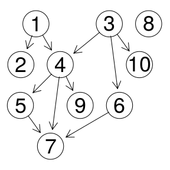

Fig.1: Random graph to be inferred with 10 nodes and regression coefficients for edges

```r
plot(dag)
```

The function `rgraph.gauss` is a wrapper for `r.gauss.pardag` in `pcalg` and returns a graph object of class `graphAM` (adjacency matrix-based graph) defined in `graph` package. The argument `prob` controls the edge probability. The DAG object also contains regression coefficients corresponding to each edge.

We generate simulated data from multivariate normal distributions corresponding to this graph:

```r
xi <- simulate.gauss(dag=dag, nsample=5000)
dim(xi)
```

```
#> [1] 5000   10
```

```r
head(xi)
```

```
#>               1          2          3           4          5           6
#> [1,]  0.8590199  0.4722603 -0.9782862 -1.39302227 -0.2867087  0.12100981
#> [2,] -0.1214747  0.2256250 -2.7088150 -3.39477625 -2.0606031  0.09336199
#> [3,] -0.7497174 -0.1598701  0.3387833 -0.83144532 -1.8729690 -0.10118943
#> [4,] -0.8416607 -1.0899544  1.3624157 -0.06423684  1.6162742 -0.66555171
#> [5,]  0.3978689  1.4492562  0.5324443  1.06764271  1.5185028 -0.30200782
#> [6,]  0.4968911  0.3468390 -0.5755399 -0.62667866 -1.2034858 -0.35590688
#>               7          8          9          10
#> [1,] -0.9189859 -0.5832588  0.4877529  1.26483764
#> [2,]  1.8136077  0.7783585  1.3220287  2.46758538
#> [3,]  0.7957343  1.6437948  1.4410567  0.05960842
#> [4,] -0.7371899 -0.7519014  1.9212855 -1.84634243
#> [5,] -0.8989691 -0.8762299 -1.1085529 -1.49493385
#> [6,]  0.6653418 -0.3106849  0.3451625 -0.35690652
```

Note that the data frame has columns corresponding to each node (column names must match those of nodes) and each row represent a single sample.

The following command performs Gibbs sampling using a random initial graph:

```
#> Computing local scores ...
#> istep = 1000, log LK = -18495.03, mean distance = 2.877
#> istep = 2000, log LK = -18496.51, mean distance = 1.704
#> istep = 3000, log LK = -18493.8, mean distance = 1.729
#> istep = 4000, log LK = -18496.85, mean distance = 1.737
#> istep = 5000, log LK = -18494.14, mean distance = 1.344
```

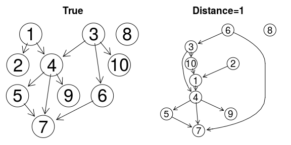

Fig.2: Comparison of true graph and DAG after 5,000 Gibbs sampling steps.

```r
par(mfrow=c(1,2))
Gibbs <- mc.sample(xi=xi, ref=dag, discrete=FALSE, nstep=5000,
                   burn.in=1000, verbose=2, q=2, kappa=3, npr=1000,
                   nplot=5000, progress.bar=FALSE)
```

The graph after 5,000 steps shown on the right is distance 1 (number of edges different, disregarding directionality) from the real DAG (false positive edge 10-to-1). The parameter `ref` is optional and is useful if a reference graph (such as the known true DAG in simulation runs) is available for comparison in order to track the progress of sampling toward the target. The parameter `discrete` is used to distinguish continuous and discrete data. Sampling will be performed for `nstep` steps in total. Each step consists of a random selection of `q` nodes and a two-step sampling of all parent sets of these nodes using a partitioning scheme designed to accelerate sampling (see Goudie & Mukherjee<sup>1</sup>). The maximum in-degree per node is set by the parameter `kappa`. The option `verbose=1` will silence the outputs. Every `npr` step, intermediate statistics (log likelihood and mean distance to the reference graph) are printed. Every `nplot` step, the reference and dynamically reached graph will be plotted side-by-side. To speed up actual sampling, likelihood scores of graphs containing the selected nodes and all possible parent sets are pre-computed and stored. The progress of this step can be tracked with `progress.bar=TRUE`. Each graph is scored using maximum likelihood scores for regression coefficients. The normal-Wishart prior conjugate to multivariate normals<sup>2</sup> can also be used but results tend to be very similar.

```r
Gibbs$edge.prob
```

```
#>       1    2   3 4    5    6 7 8 9   10
#> 1  0.00 0.25 0.0 1 0.00 0.00 0 0 0 0.00
#> 2  0.75 0.00 0.0 0 0.00 0.00 0 0 0 0.00
#> 3  0.00 0.00 0.0 1 0.00 0.50 0 0 0 0.50
#> 4  0.00 0.00 0.0 0 1.00 0.00 1 0 1 0.25
#> 5  0.00 0.00 0.0 0 0.00 0.00 1 0 0 0.00
#> 6  0.00 0.00 0.5 0 0.00 0.00 1 0 0 0.00
#> 7  0.00 0.00 0.0 0 0.00 0.00 0 0 0 0.00
#> 8  0.00 0.00 0.0 0 0.00 0.25 0 0 0 0.00
#> 9  0.00 0.00 0.0 0 0.25 0.00 0 0 0 0.00
#> 10 0.50 0.00 0.5 0 0.00 0.00 0 0 0 0.00
```

The `(i,j)` element of this matrix is the fraction of times the edge from node `i` to node `j` was “on”, sampled every `npr` steps after discarding the first `burn.in` period. We construct a consensus graph using cutoff 0.5:

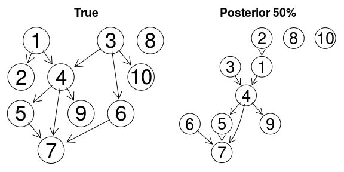

Fig.3: Comparison of true graph and consensus DAG with edges of posterior probability > 0.5.

```r
A <- apply(Gibbs$edge.prob, 1:2, function(x){as.numeric(x>0.5)})
pdag <- graph::graphAM(adjMat=A, edgemode='directed')
par(mfrow=c(1,2))
plot(dag, main='True')
plot(pdag, main='Posterior 50%')
```

## Discrete data

Discrete data sets are treated similarly. We perform an inference below for  
discrete data from a graph with 12 nodes:

```r
p <- 12
set.seed(2)
nodes <- as.character(1:p)
dag <- rgraph(nodes=nodes, mean.degree=1.5, alpha=c(1,1), max.degree=3)
dag
```

```
#> A graphAM graph with directed edges
#> Number of Nodes = 12
#> Number of Edges = 11
```

```r
xi <- simulate.data(dag=dag, nsample=10000)
head(xi)
```

```
#>   1 2 3 4 5 6 7 8 9 10 11 12
#> 1 1 2 1 1 1 1 1 1 2  2  1  2
#> 2 1 2 1 1 1 1 2 1 2  1  1  2
#> 3 1 2 2 1 1 1 2 2 2  1  1  2
#> 4 1 2 1 2 1 1 1 1 2  1  2  2
#> 5 1 2 2 2 1 1 2 2 2  1  1  2
#> 6 1 2 1 1 1 2 1 1 2  1  2  2
```

```r
par(mfrow=c(1,2))
Gibbs <- mc.sample(xi=xi, ref=dag, discrete=TRUE, nstep=20000, verbose=2,
                   progress.bar=FALSE, burn.in=1000, npr=1000, nplot=30000, q=2, kappa=3)
```

```
#> Computing local scores ...
#> istep = 1000, log LK = -65659.53, mean distance = 3.27
#> istep = 2000, log LK = -65662.75, mean distance = 3.104
#> istep = 3000, log LK = -65659.53, mean distance = 3.098
#> istep = 4000, log LK = -65654.57, mean distance = 2.392
#> istep = 5000, log LK = -65654.57, mean distance = 2
#> istep = 6000, log LK = -65654.57, mean distance = 2
#> istep = 7000, log LK = -65654.57, mean distance = 2
#> istep = 8000, log LK = -65654.57, mean distance = 2
#> istep = 9000, log LK = -65654.84, mean distance = 2
#> istep = 10000, log LK = -65654.57, mean distance = 2
#> istep = 11000, log LK = -65653.95, mean distance = 2
#> istep = 12000, log LK = -65653.95, mean distance = 2
#> istep = 13000, log LK = -65653.68, mean distance = 2
#> istep = 14000, log LK = -65653.95, mean distance = 2
#> istep = 15000, log LK = -65653.68, mean distance = 2
#> istep = 16000, log LK = -65653.68, mean distance = 2
#> istep = 17000, log LK = -65653.95, mean distance = 2
#> istep = 18000, log LK = -65653.68, mean distance = 2
#> istep = 19000, log LK = -65653.68, mean distance = 2
#> istep = 20000, log LK = -65653.68, mean distance = 2
```

Although discrete data `xi` above are all binary, factors with varying number of levels for each variable in real data sets can also be used as input to `mc.sample`. Scoring uses the Dirichlet prior conjugate to multinomials with a uniform hyperparameter of prior count 1<sup>3</sup>. The local score computation above will take about 5 min; turn on the option `progress.bar=TRUE` to track this step.

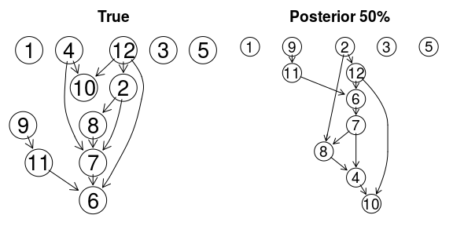

Fig.5: True graph and posterior 50% DAG for discrete data.

```r
A <- apply(Gibbs$edge.prob, 1:2, function(x){as.numeric(x>0.5)})
pdag <- graph::graphAM(adjMat=A, edgemode='directed')
par(mfrow=c(1,2))
plot(dag, main='True')
plot(pdag, main='Posterior 50%')
```

The posterior edge graph above again agrees well with true graph.

## References

1. Goudie, R. J. B. & Mukherjee, S. A Gibbs sampler for learning DAGs. *J. Mach. Learn. Res.* **17,** 1–39 (2016).

2. Geiger, D. & Heckerman, D. Learning gaussian networks. in *Proceedings of the tenth international conference on uncertainty in artificial intelligence* 235–243 (Morgan Kaufmann Publishers Inc., 1994).

3. Heckerman, D., Geiger, D. & Chickering, D. M. Learning Bayesian networks: The combination of knowledge and statistical data. *Mach. Learn.* **20,** 197–243 (1995).